# Graphical and Simplex Methods

# Graphical Method

## Maximization

$$\begin{align}
P = 4_{x1} + 5_{x2} \\
2_{x1} + 3_{x2} \leq 120 \\
2_{x1} + 1.5_{x2} \leq 80 \\
x1, x2 \geq 0
\end{align}$$
The *objective function* is $P = 4_{x1} + 5_{x2}$. Every other equation is a *contraint*. Without constraints, our optimization will do just that – optimize (much like my younger brother, they tend to be lazy and greedy).

If we want to put some concrete terms to our equations, we could specify something as follows:

*P* is profit (of course we want to maximize profit).

For every piece that machine 1 makes, we make $4. For every piece that machine 2 makes, we make $5

For every piece made, machine 1 requires 2 pounds of filings and machine 2 requires 3 pounds. We currently have 120 pounds of filings.

For every piece made, machine 1 requires 2 pounds of resin and machine 2 requires 1.5 pounds. We currently have 80 pounds of filings.

$x^1$ is number of pieces for machine 1

$x^2$ is number of pieces for machine 2

To begin, we need to express our inequalities as equations:

$$\begin{align}
2_{x1} + 3_{x2} = 120 \\
2_{x1} + 1.5_{x2} = 80 \\
x1 = 0 \\
x2 = 0
\end{align}$$

This will let us define all ordered pairs that will satisfy the equations.

Our first equation, $2_{x1} + 3_{x2} = 120$ can be solved as $(2 * 0) + (3 * 40) = 120$ or as $(2 * 60) + (3 * 0) = 120$. For that equation, we have both $(x_1 = 0, x_2 = 40)$ and $(x_1 = 60, x_2 = 0)$.

For our second equation, $2_{x1} + 1.5_{x2} = 80$, we can solve that as $(2 * 0) + (1.5 * 53.33) = 80$ or as $(2 * 40) + (1.5 * 0) = 80$. For that equation, we have both $(x_1 = 0, x_2 = 53.33)$ and $(x_1 = 40, x_2 = 0)$.

We can plot those points:

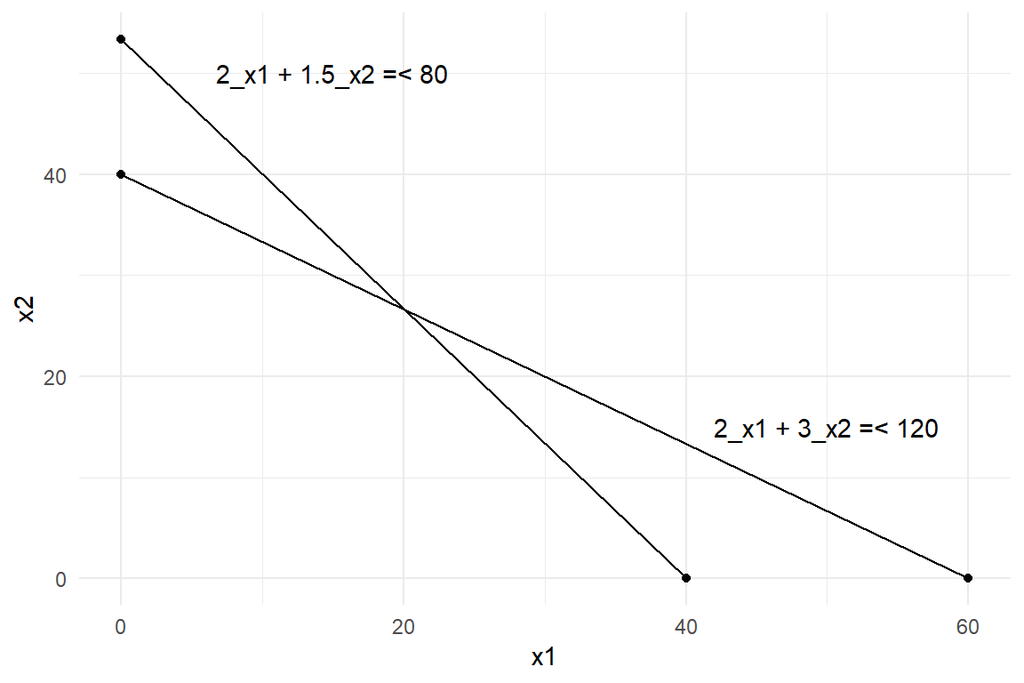

```r
library(dplyr)

library(ggplot2)

graphPoints = data.frame(x = c(0, 60, 0, 40),
    y = c(40, 0, 53.33, 0),
    eq = as.factor(c(1, 1, 2, 2)))

ggplot(graphPoints, aes(x, y, group = eq)) +
  geom_point() +
  geom_line() +
  theme_minimal() +
  annotate("text", x = 15, y = 50, label = "2_x1 + 1.5_x2 =< 80") +
  annotate("text", x = 50, y = 15, label = "2_x1 + 3_x2 =< 120") +
  labs(x = "x1", y = "x2")
```

We can start to define the feasible region for our solution:

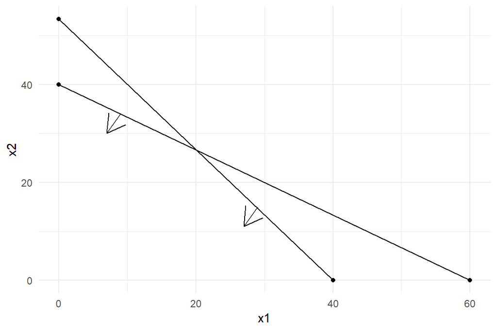

```r
ggplot() +
  geom_point(data = graphPoints, mapping = aes(x, y, group = eq)) +
  geom_line(data = graphPoints, mapping = aes(x, y, group = eq)) +
  geom_segment(mapping = aes(x = 9, xend = 7,
               y = 34, yend = 30), arrow = arrow()) +
  geom_segment(mapping = aes(x = 29, xend = 27,
               y = 15, yend = 11), arrow = arrow()) +
  theme_minimal() +
  labs(x = "x1", y = "x2")
```

If we consider our constraints, we would probably be working within this region:

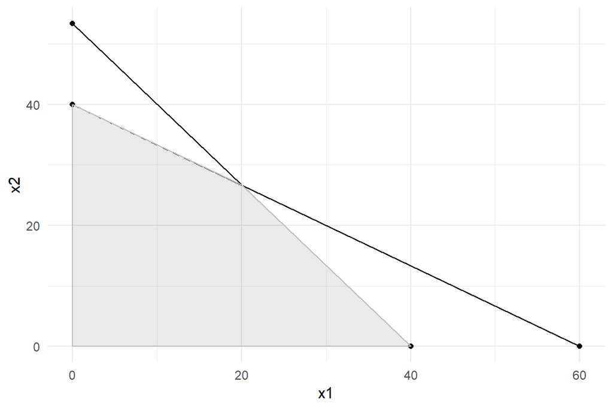

```r
ggplot() +
  geom_point(data = graphPoints, mapping = aes(x, y, group = eq)) +
  geom_line(data = graphPoints, mapping = aes(x, y, group = eq)) +
  geom_polygon(data = data.frame(x = c(0, 40, 20, 0),
                               y = c(0, 0, 26.67, 40)),
            mapping = aes(x, y), color = "grey", alpha = .1) +
  theme_minimal() +
  labs(x = "x1", y = "x2")
```

If we want to maximize our function, then we are going to need to look at every ordered pair within the feasible region to get to the optimized solution – that should not take you too long to do by hand…

Or, if you actually want to move along with your life, we can use the *extreme point theorem*:

The optimal value of the objective function occurs at one of the extreme points of the feasible region.

Where are our extreme values? Right here!

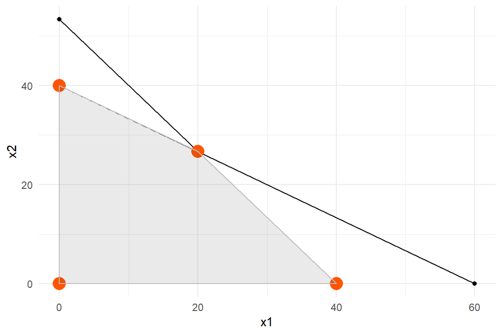

```r
ggplot() +
  geom_point(data = graphPoints, mapping = aes(x, y, group = eq)) +
  geom_line(data = graphPoints, mapping = aes(x, y, group = eq)) +
  geom_point(data = data.frame(x = c(0, 40, 20, 0),
                               y = c(0, 0, 26.67, 40)),
             mapping = aes(x, y), color = "#ff5500", size = 5) +
  geom_polygon(data = data.frame(x = c(0, 40, 20, 0),
                               y = c(0, 0, 26.67, 40)),
            mapping = aes(x, y), color = "grey", alpha = .1) +
  theme_minimal() +
  labs(x = "x1", y = "x2")
```

Now that we know our extreme values, it is just a matter of finding which will give us the maximum value:

```r
extremePoints = data.frame(x = c(0, 40, 20, 0),
                           y = c(0, 0, 26.67, 40))

x1 = 4

x2 = 5

(x1 * extremePoints$x) + (x2 * extremePoints$y)
```

```
[1]   0.00 160.00 213.35 200.00
```

```r
extremePoints = data.frame(x = c(0, 40, 20, 0),
                           y = c(0, 0, 26.67, 40))

x1 = 4

x2 = 5

(x1 * extremePoints$x) + (x2 * extremePoints$y)
```

```
[1]   0.00 160.00 213.35 200.00
```

```r
library(linprog)

c = c(4, 5)

b = c(120, 80)

A = rbind(c(2, 3), c(2, 1.5))

res = solveLP(c, b, A, maximum = TRUE)

res
```

```
Results of Linear Programming / Linear Optimization

Objective function (Maximum): 213.333

Iterations in phase 1: 0
Iterations in phase 2: 2
Solution
      opt
1 20.0000
2 26.6667

Basic Variables
      opt
1 20.0000
2 26.6667

Constraints
  actual dir bvec free     dual dual.reg
1    120  <=  120    0 1.333333       40
2     80  <=   80    0 0.666667       20

All Variables (including slack variables)
        opt cvec   min.c    max.c      marg marg.reg
1   20.0000    4 3.33333 6.666667        NA       NA
2   26.6667    5 3.00000 6.000000        NA       NA
S 1  0.0000    0    -Inf 1.333333 -1.333333       40
S 2  0.0000    0    -Inf 0.666667 -0.666667       20
```

## Minimization

If our object function is to minimize, we need to tweak things just a bit. Consider the following:

$$\begin{align}
C = 50_{x1} + 20_{x2} \\
2_{x1} - 1_{x2} \geq 0 \\
1_{x1} + 4_{x2} \geq 80 \\
.9_{x1} + .8_{x2} \geq 40 \\
x1, x2 \geq 0
\end{align}$$

This isn’t anything we haven’t seen, but it has taken a slightly different form. Before our goal was to maximize profit; now, though, our goal is minimize cost.

We can work through our constraints in the same fashion as before.

$2_{x1} - 1_{x2} = 0$ has a set of $(x_1 = 0, x_2 = 0) or (x_1 = 30, x_2 = 60)$, $1_{x1} + 4_{x2} = 80$ has a set of $(x_1 = 0, x_2 = 20) or (x_1 = 80, x_2 = 0)$, and $.9_{x1} + .8_{x2} = 40$ has a set of $(x_1 = 44.44, x_2 = 0) or (x_1 = 0, x_2 = 50)$.

Why, in the name of all that is holy, would that first equation not reduce down further? If we plot things, we will find out pretty quickly:

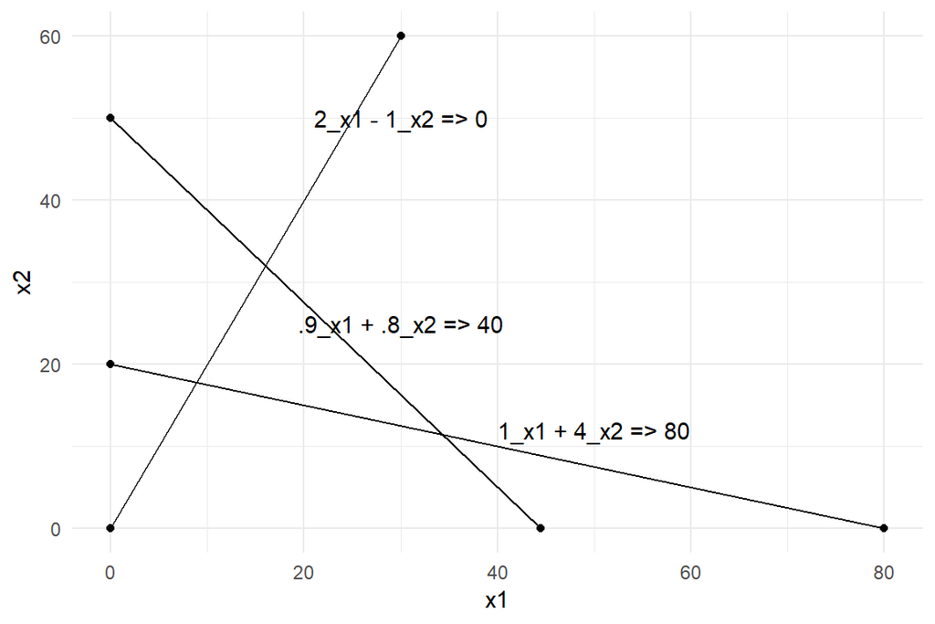

```r
graphPoints = data.frame(x = c(0, 30, 0, 80, 44.44, 0),
    y = c(0, 60, 20, 0, 0, 50),
    eq = as.factor(c(1, 1, 2, 2, 3, 3)))

ggplot(graphPoints, aes(x, y, group = eq)) +
  geom_point() +
  geom_line() +
  theme_minimal() +
  annotate("text", x = 30, y = 50, label = "2_x1 - 1_x2 => 0") +
  annotate("text", x = 50, y = 12, label = "1_x1 + 4_x2 => 80") +
  annotate("text", x = 30, y = 25, label = ".9_x1 + .8_x2 => 40") +
  labs(x = "x1", y = "x2")
```

We still want to find our extreme points, but remember that we are looking at a minimized objective function. To that end, our feasible region is going to be in a different place

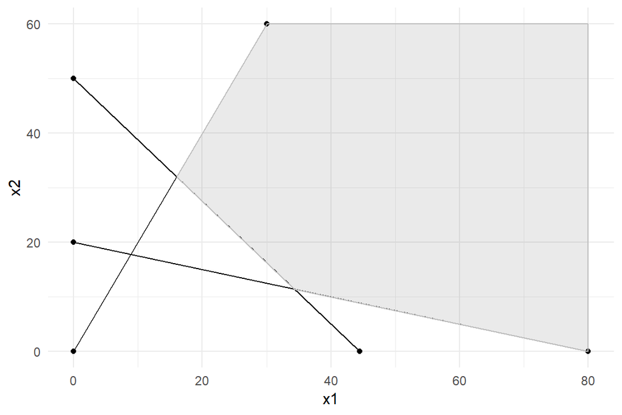

```r
ggplot() +
  geom_point(data = graphPoints, mapping = aes(x, y, group = eq)) +
  geom_line(data = graphPoints, mapping = aes(x, y, group = eq)) +
  geom_polygon(data = data.frame(x = c(16, 34.32, 80, 80, 30),
                               y = c(32, 11.42, 0, 60, 60)),
            mapping = aes(x, y), color = "grey", alpha = .1) +
  theme_minimal() +
  labs(x = "x1", y = "x2")
```

This will help us to find our extreme points for testing:

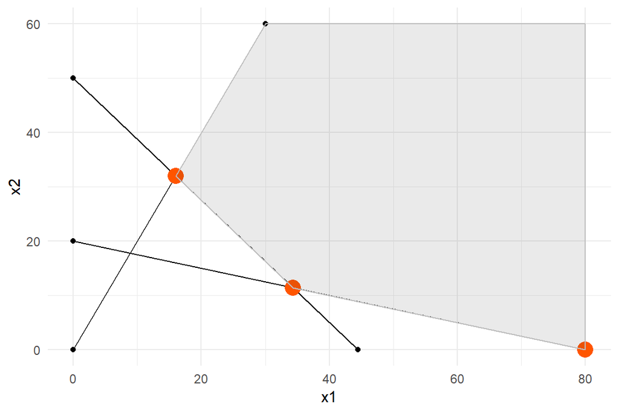

```r
ggplot() +
  geom_point(data = graphPoints, mapping = aes(x, y, group = eq)) +
  geom_line(data = graphPoints, mapping = aes(x, y, group = eq)) +
    geom_point(data = data.frame(x = c(16, 34.32, 80),
                               y = c(32, 11.42, 0)),
             mapping = aes(x, y), color = "#ff5500", size = 5) +
  geom_polygon(data = data.frame(x = c(16, 34.32, 80, 80, 30),
                               y = c(32, 11.42, 0, 60, 60)),
            mapping = aes(x, y), color = "grey", alpha = .1) +
  theme_minimal() +
  labs(x = "x1", y = "x2")
```

Excellent. Now we can solve for those extreme values and get our solution:

```r
extremePoints = data.frame(x1 = c(16, 34.32, 80),
                               x2 = c(32, 11.42, 0))

x1 = 50

x2 = 20

(x1 * extremePoints$x1) + (x2 * extremePoints$x2)
```

```
[1] 1440.0 1944.4 4000.0
```

With our cost minimized to 1440, we should select 16 for x1 and 32 for x2.

Just for giggles, we can through our solution back into our original equations to see what comes up:

```r
solutionX1 = 16

solutionX2 = 32

(2 * solutionX1) - (1 * solutionX2) # Equation 1 => 0
```

```
[1] 0
```

```r
(1 * solutionX1) + (4 * solutionX2) # Equation 2 => 80
```

```
[1] 144
```

```r
(.9 * solutionX1) + (.8 * solutionX2) # Equation 3 => 40
```

```
[1] 40
```

### Your Turn

Try to find an optimal solution to this problem:

$$\begin{align}
P = 4_{x1} + 3_{x2} \\
21_{x1} + 16_{x2} \leq 336 \\
13_{x1} + 25_{x2} \leq 325 \\
15_{x1} + 18_{x2} \leq 270 \\
x1, x2 \geq 0
\end{align}$$

# Simplex Method

The graphical method works, but can become unwieldy as we add constraints.

The Simplex Method is one of those methods that is old (1947), but still still useful. When trying to set an objective function to linear functions, the Simplex Method can be used.

There are several steps and rules to solving a problem with the simplex method. The first step is to convert our constraint inequalities to equations. This conversion will happen with *slack variables* and *surplus variables*. For example, we would take the following inequalities:

$$\begin{align}
P = x1 + x2 \\
3_{x1} + 2_{x2} \leq 40 \\
2_{x1} + {x2} \geq 10 \\
\end{align}$$

And convert them to equations with slack variable $x3$ and surplus variable $x4$

$$\begin{align}
3_{x1} + 2_{x2} + x3 = 40 \\
2_{x1} + {x2} - x4 = 10 \\
\end{align}$$

But now we arrive at an interesting issue: we have 2 equations (*m*) and 4 variables (*n*). Whenver $n > m$, we have an infinite number of solutions (sound familiar so far?).

This is what is known as a consistent equation system

With this group of variables and equations, we can apply the *basis theorem*. The basis theorem tell that *for a system of m equations and n variables, where n > m, a solution in which at least n - m of the variables have values of zero at the extreme points*. With 4 variables and 2 equations, we have at least 2 variables that are 0. Substituting 0 in for variables will give us an idea of our *basic solutions*.

If we set *x3* and *x4* to 0, we get the following 2 equations:

$$\begin{align}
3_{x1} + 2_{x2} = 40 \\
2_{x1} + {x2} = 10 \\
\end{align}$$

In the equations above, we could set $x1 = -20$ and $x2 = 50$ to solve the equations simultaneously. The negative variable does not work for us, so we need to look at other combinations of 0.

We could also set *x1* and *x2* to 0 to get the following:

$$\begin{align}
x3 = 40 \\
-x4 = 10 \\
\end{align}$$

Also not going to work! What setting *x1* and *x3* to 0:

$$\begin{align}
2_{x2} = 40 \\
{x2} - x4 = 10 \\
\end{align}$$

What is *x2* and what is *x4*?

Now we can do the same thing with every other combination:

| x1 | x2 | x3 | x4 | objective |
| --- | --- | --- | --- | --- |
| 0.0 | 0 | 40 | -10.0 | 0.0 |
| 0.0 | 20 | 0 | 10.0 | 20.0 |
| 0.0 | 10 | 20 | 0.0 | 10.0 |
| 13.3 | 0 | 0 | 16.6 | 13.3 |
| 5.0 | 0 | 25 | 0.0 | 5.0 |
| -20.0 | 50 | 0 | 0.0 | 30.0 |

Remember, anything with negative variable values is nonfeasible!